# CPS305 Fall 2019

## Lab $02$ Report

## Parth Patel, Std ID 500893723

20 Sept 2019

# Introduction and Overall Comments

This is the submission of Parth Patel.

## Solution for exercise 1

```
<function matplotlib.pyplot.figure(num=None, figsize=None, dpi=None, facecolor=None, edgecolor=None, frameon=True, FigureClass=<class 'matplotlib.figure.Figure'>, clear=False, **kwargs)>
```

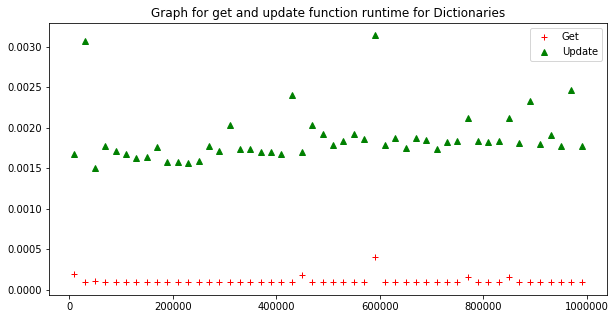

```python
# Python code and its output for "get and update" function

import timeit
import random
from matplotlib import pyplot as plt


#for graph
yAxisForGet = []
xAxisForGet = []
yAxisForUpdate = []
xAxisForUpdate = []


for i in range(10000,1000001,20000):
    t_Get = timeit.Timer("x.get('random.randrange(i)')",
                     "from __main__ import random,x")

    t_Update = timeit.Timer("x.update({random.randrange(%d):None})"%i,
                     "from __main__ import random,x")

    x = {j:None for j in range(i)}

    dict_time_forGet = t_Get.timeit(number=1000)
    dict_time_forUpdate = t_Update.timeit(number=1000)

    xAxisForGet.append(i)
    yAxisForGet.append(dict_time_forGet)

    xAxisForUpdate.append(i)
    yAxisForUpdate.append(dict_time_forUpdate)

plt.figure(figsize = (10,5))
plt.plot(xAxisForGet, yAxisForGet,"r+")
plt.plot(xAxisForUpdate, yAxisForUpdate, "g^")
plt.title('Graph for get and update function runtime for Dictionaries')
plt.legend(['Get', 'Update'], loc = 0)
plt.figure
```

**Discussion of the Results**

This code is the answer for the first question in which we determine if the get and update methods in Dictionary data type are the same order of operation that is O(1). From the graph obtained we can clearly see that both the functions are indepentent of time and no matter how big the number gets it would not affect the runtimes of either of the functions/methods.

## Solution for Exercise 2

```
<function matplotlib.pyplot.figure(num=None, figsize=None, dpi=None, facecolor=None, edgecolor=None, frameon=True, FigureClass=<class 'matplotlib.figure.Figure'>, clear=False, **kwargs)>
```

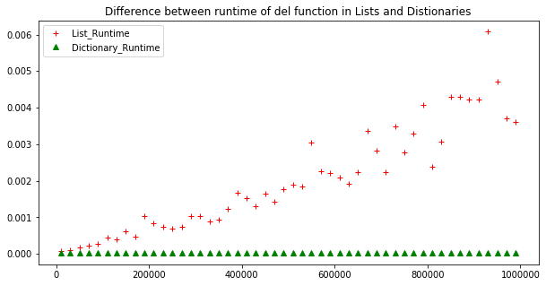

```python
import timeit
import random
from matplotlib import pyplot as plt


#for graph
yAxisForList = []
xAxisForList = []
yAxisForDict = []
xAxisForDict = []


for i in range(10000,1000001,20000):
    t_list = timeit.Timer("del test_list[random.randrange(%d)]"%i,"from __main__ import random,test_list")

    t_dict = timeit.Timer("del test_dict[random.randrange(%d)]"%i,"from __main__ import random,test_dict")

    test_list = [j for j in range(i)]
    test_dict= {j:None for j in range(i)}

    list_time = t_list.timeit(number=10)
    dict_time = t_dict.timeit(number=10)

    xAxisForList.append(i)
    yAxisForList.append(list_time)

    xAxisForDict.append(i)
    yAxisForDict.append(dict_time)

plt.figure(figsize = (10,5))
plt.plot(xAxisForList, yAxisForList,"r+")
plt.plot(xAxisForDict, yAxisForDict, "g^")
plt.title('Difference between runtime of del function in Lists and Distionaries')
plt.legend(['List_Runtime', 'Dictionary_Runtime'], loc = 0)
plt.figure
```

**Discussion of the Results**

This code is the answer for the second question in which we compare the runtimes of del function on list and dictionary data types. From the graph obtained it can be derived that del funcation is independent of time for dictionaty data type that is O(1). But, it is a linear function when it comes to lists that means it's Big-O representation is O(n) which means its runtime increases when n gets bigger.